# James RBIF 125 Final

Author: James Hinojosa

Last update: 27 July, 2026

# 1 Download data set from GEO

The code below will define a function to download a data set from the Gene Expression Omnibus (GEO). This code provides a way to download either an Array or RNAseq dataset.

```r
# Installs necessary packages if not already installed
# BiocManager::install("DESeq2")
# BiocManager::install("limma")
# install.packages("data.table")
# BiocManager::install("sva")
# install.packages('R.utils')
library(DESeq2); library(limma); library(data.table); library(ggplot2); library(sva); library(R.utils)

# Creates function to download data from GEO
GEODataDownload <- function(DS, gpl, gsm, PlateAnnotInfo, GenerateMetaData, Technology){
  library(DESeq2); library(limma); library(data.table)

  # Defines downloading an "Array" dataset
  if(Technology == "Array"){
    gset <- getGEO(DS)
    if(length(gset) > 1) idx <- grep(gpl, attr(gset, "names")) else idx <- 1
    gset <- gset[[idx]]
    fvarLabels(gset) <- make.names(fvarLabels(gset))
    comp <- gsub(" ", "", gsm)
    comp <- gsub(",", "", comp)
    gsms <- paste0(comp)

    # Sets up raw names
    sml <- c()
    for(i in 1:nchar(gsms)){ sml[i] <- substr(gsms,i,i)}
    ex <- exprs(gset)
    qx <- as.numeric(quantile(ex, c(0., 0.25, 0.5, 0.75, 0.99, 1.0), na.rm=T))
    LogC <- (qx[5] > 100) ||
      (qx[6]-qx[1] > 50 && qx[2] > 0) ||
      (qx[2] > 0 && qx[2] < 1 && qx[4] < 2)
    if(LogC){ ex[which(ex <= 0)] <- NaN
    exprs(gset) <- log2(ex) }
    sml <- paste("G", sml, sep="")
    f1 <- as.factor(sml)
    gset$description2 <- f1
    design <- model.matrix(~description2 + 0, gset)
    colnames(design) <- levels(f1)
    fit <- lmFit(gset, design)
    cont.matrix <- makeContrasts(G1-G0, levels = design)
    fit2 <- contrasts.fit(fit, cont.matrix)
    fit2 <- eBayes(fit2, 0.01)
    tT <- topTable(fit2, adjust="fdr", sort.by = "B", number = 25000000000)

    # Subsets data
    ex2 <- data.table(subset(tT, select=c("ID", "logFC", "P.Value", "adj.P.Val")))
    ex2$ID <- as.character(ex2$ID)

    # Annotates with gene names
    plat <- PlateAnnotInfo[GPLID == gpl,][,!"GPLID", with = FALSE]
    if(nrow(plat) == 0){ print(paste("There is no annotation information available for", gpl)) }
    plat$ID <- as.character(plat$ID)
    plat <- plat[!duplicated(plat$ID),]
    ex2 <- merge(plat, ex2, by = "ID")
    ex2$ID <- as.character(ex2$ID)
    exraw <- data.table(ex)
    exraw$ID <- as.character(rownames(ex))

    # Annotates raw data with gene names
    ex2 <- merge(ex2, exraw, by = "ID")

    # Generates Metadata
    Pdat <- pData(gset)

    # Adds Metadata
    Pdat <- as.data.table(Pdat)
    return(list(Data = ex2, MetaData = Pdat))
  }

  # Defines downloading an "RNAseq" dataset
  if(Technology == "RNAseq"){
    ACC <- paste("acc=", DS, sep = "")
    file <- paste("file=", DS, "_raw_counts_GRCh38.p13_NCBI.tsv.gz", sep = "")
    comp <- gsub(" ", "", gsm)
    comp <- gsub(",", "", comp)
    gsms <- paste0(comp)

    # Sets up DEG names
    urld <- "https://www.ncbi.nlm.nih.gov/geo/download/?format=file&type=rnaseq_counts"
    path <- paste(urld, ACC, file, sep="&");
    tbl <- as.matrix(data.table::fread(path, header=T, colClasses="integer"), rownames="GeneID")
    exraw <- tbl
    apath <- paste(urld, "type=rnaseq_counts", "file=Human.GRCh38.p13.annot.tsv.gz", sep="&")
    annot <- data.table::fread(apath, header=T, quote="", stringsAsFactors=F, data.table=F)
    rownames(annot) <- annot$GeneID
    sml <- strsplit(gsms, split="")[[1]]
    sel <- which(sml != "X")
    sml <- sml[sel]
    tbl <- tbl[ ,sel]
    gs <- factor(sml)
    groups <- make.names(c("Ctrl", "Tx"))
    levels(gs) <- groups
    sample_info <- data.frame(Group = gs, row.names = colnames(tbl))
    keep <- rowSums( tbl >= 10 ) >= min(table(gs))
    tbl <- tbl[keep, ]
    ds <- DESeqDataSetFromMatrix(countData=tbl, colData=sample_info, design= ~Group)
    ds <- DESeq(ds, test="Wald", sfType="poscount")
    r <- results(ds, contrast=c("Group", groups[2], groups[1]), alpha=0.05, pAdjustMethod ="fdr")
    tT <- r[order(r$padj)[1:length(r$padj)],]
    tT <- merge(as.data.frame(tT), annot, by=0, sort=F)
    tT <- subset(tT, select=c("GeneID","padj","pvalue","lfcSE","stat","log2FoldChange","baseMean","Symbol","Description"))

    # Subsets data
    ex2 <- data.table(subset(tT, select=c("GeneID", "Symbol", "Description", "log2FoldChange", "pvalue", "padj")))

    # Adjusts column names
    setnames(ex2, c("GeneID", "Symbol", "Description"), c("ENTREZID", "SYMBOL", "GENENAME"))

    # Gets raw data
    GeneID <- as.integer(rownames(exraw))
    exraw <- as.data.table(exraw)

    # Updates column names
    exraw$ENTREZID <- GeneID

    # Merges FC and raw data together
    mer <- merge(ex2, exraw, by = "ENTREZID")
    return(mer)
  }
}
```

With this function now defined, a data set from GEO can now be downloaded using the code below. This code downloaded a GEO RNAseq dataset that evaluated the differences in gene expression levels of the nucleus accumbens between cigarette smokers and non-smokers [1] and was saved as `data`.

```r
# Downloads smokers vs non-smokers data set
data <- GEODataDownload(DS = "GSE171936",
                              gpl = "GPL21290",
                              gsm = "000000001101000000001000010000000001100010101101110100000000…",
                              PlateAnnotInfo = "Only needed if the data was generated using MicroArrays",
                              GenerateMetaData = "Only needed if the data was generated using MicroArrays",
                              Technology = "RNAseq")

# Confirms successful download of dataset by showing first three rows of data set
data.table(head(as.data.frame(data),3), filter = 'top', options = list(pageLength = 10, scrollX = TRUE, scrollY = "400px", autoWidth = TRUE))
```

```
##    ENTREZID SYMBOL                           GENENAME log2FoldChange     pvalue
##       <int> <char>                             <char>          <num>      <num>
## 1:        1   A1BG             alpha-1-B glycoprotein     0.11058284 0.03737103
## 2:        2    A2M              alpha-2-macroglobulin    -0.15263425 0.02309197
## 3:        3  A2MP1 alpha-2-macroglobulin pseudogene 1     0.03685067 0.75032952
## 4:        1   A1BG             alpha-1-B glycoprotein     0.11058284 0.03737103
##         padj GSM5237605 GSM5237606 GSM5237607 GSM5237608 GSM5237609 GSM5237610
##        <num>      <int>      <int>      <int>      <int>      <int>      <int>
## 1: 0.5426683        122        117         94        147        131        236
## 2: 0.4685731       3168       3503       2317       9548       9310       6603
## 3: 0.9747033         33         18         13         21         24         13
## 4: 0.5426683        122        117         94        147        131        236
##    GSM5237611 GSM5237612 GSM5237613 GSM5237614 GSM5237615 GSM5237616 GSM5237617
##         <int>      <int>      <int>      <int>      <int>      <int>      <int>
## 1:        129        156        118        174         96        136        175
## 2:       6697      12650       6299       5894       3309       3071       6474
## 3:         39         23         14         12         20         11          7
## 4:        129        156        118        174         96        136        175
##    GSM5237618 GSM5237619 GSM5237620 GSM5237621 GSM5237622 GSM5237623 GSM5237624
##         <int>      <int>      <int>      <int>      <int>      <int>      <int>
## 1:        141        105        130         79        132        132         98
## 2:       5769       1855       6690       7096       8642       4650       4328
## 3:         29         16         17         16         22         35         21
## 4:        141        105        130         79        132        132         98
##    GSM5237625 GSM5237626 GSM5237627 GSM5237628 GSM5237629 GSM5237630 GSM5237631
##         <int>      <int>      <int>      <int>      <int>      <int>      <int>
## 1:        127        148        145        125         94        119         89
## 2:       5222       8904       8246       4515       7243       3705       4139
## 3:         17         12         27         30          8          7         15
## 4:        127        148        145        125         94        119         89
##    GSM5237632 GSM5237633 GSM5237634 GSM5237635 GSM5237636 GSM5237637 GSM5237638
##         <int>      <int>      <int>      <int>      <int>      <int>      <int>
## 1:        125        100        134        148         71        159        116
## 2:       4447       4082       6093       4276       4187       4107       3806
## 3:         33         16         14         11         33         14         33
## 4:        125        100        134        148         71        159        116
##    GSM5237639 GSM5237640 GSM5237641 GSM5237642 GSM5237643 GSM5237644 GSM5237645
##         <int>      <int>      <int>      <int>      <int>      <int>      <int>
## 1:        117        165        123         75         81        105         87
## 2:       9956       5913       5776       7320       6381       3990       4894
```

[output cut: 149 more lines]

```
## 2:       3717       5198       4619       4906       3838      13547       4013
## 3:         19         23         22         35         41         25         25
## 4:        135        109        105        117        143         51        120
##    GSM5237821 GSM5237822 GSM5237823 GSM5237824 GSM5237825 GSM5237826 GSM5237827
##         <int>      <int>      <int>      <int>      <int>      <int>      <int>
## 1:        117         95        154        121        179        160         72
## 2:       6972       3125       4008       3923      11902       6772       1622
## 3:          7         25          8         20         27         39          7
## 4:        117         95        154        121        179        160         72
##    filter options
##    <char>  <list>
## 1:    top      10
## 2:    top    TRUE
## 3:    top   400px
## 4:    top    TRUE
```

The metadata for this data set was downloaded from the GEO website and saved to my working directory. This metadata csv file was loaded into this session using the code below.

```r
# Loads meta data csv file into session
DT <- fread("metadata.csv")

# Displays first few lines of meta data csv file
head(DT)
```

```
##            Run age_at_death Assay Type AvgSpotLen      Bases  BioProject
##         <char>        <num>     <char>      <int>      <i64>      <char>
## 1: SRR14227576        52.57    RNA-Seq        202 6594639056 PRJNA721610
## 2: SRR14227577        52.57    RNA-Seq        202 6608233050 PRJNA721610
## 3: SRR14227578        21.01    RNA-Seq        202 6496261622 PRJNA721610
## 4: SRR14227579        21.01    RNA-Seq        202 6365672864 PRJNA721610
## 5: SRR14227580        57.89    RNA-Seq        202 6501794604 PRJNA721610
## 6: SRR14227581        57.89    RNA-Seq        202 6915602714 PRJNA721610
##       BioSample      Bytes Center Name Consent current_smoking_status
##          <char>      <i64>      <char>  <char>                 <char>
## 1: SAMN18723351 2843303557         GEO  public                control
## 2: SAMN18723351 2814202658         GEO  public                control
## 3: SAMN18723350 2414013250         GEO  public                control
## 4: SAMN18723350 2358862223         GEO  public                control
## 5: SAMN18723380 2640099236         GEO  public                control
```

[output cut: 33 more lines]

# 2 Exploratory Analysis

With data set and meta data loaded into the session, exploratory analysis can begin using the code below. First we must evaluate the data set for any missing information and adjust accordingly.

```r
# Isolates sample name, current smoking status, and age at death from meta data
meta <- DT[, c("GEO_Accession (exp)", "current_smoking_status", "age_at_death")]
meta <- unique(meta)

# Identifies meta data for control samples
controls <- meta[meta$current_smoking_status == "control"]
head(controls)
```

```
##    GEO_Accession (exp) current_smoking_status age_at_death
##                 <char>                 <char>        <num>
## 1:          GSM5237605                control        52.57
## 2:          GSM5237606                control        21.01
## 3:          GSM5237607                control        57.89
## 4:          GSM5237608                control        63.00
## 5:          GSM5237609                control        26.51
## 6:          GSM5237610                control        57.60
```

```r
dim(controls)
```

```
## [1] 171   3
```

```r
# Identifies meta data for test samples
cases <- meta[meta$current_smoking_status == "case"]
head(cases)
```

```
##    GEO_Accession (exp) current_smoking_status age_at_death
##                 <char>                 <char>        <num>
## 1:          GSM5237613                   case        58.48
## 2:          GSM5237614                   case        48.66
## 3:          GSM5237616                   case        59.58
## 4:          GSM5237625                   case        54.48
## 5:          GSM5237630                   case        41.17
## 6:          GSM5237640                   case        60.72
```

```r
dim(cases)
```

```
## [1] 50  3
```

```r
# Identifies samples with unknown smoking status
unknown.status <- meta[meta$current_smoking_status == "indeterminant"]
unknown.status
```

```
##    GEO_Accession (exp) current_smoking_status age_at_death
##                 <char>                 <char>        <num>
## 1:          GSM5237811          indeterminant           NA
## 2:          GSM5237813          indeterminant           NA
```

```r
dim(unknown.status)
```

```
## [1] 2 3
```

```r
# Identifies samples with unknown age
unknown.age <- meta[is.na(meta$age_at_death),]
unknown.age
```

```
##    GEO_Accession (exp) current_smoking_status age_at_death
##                 <char>                 <char>        <num>
## 1:          GSM5237811          indeterminant           NA
## 2:          GSM5237813          indeterminant           NA
```

```r
dim(unknown.age)
```

```
## [1] 2 3
```

```r
# Isolates sample names with incomplete information
unknowns <- unknown.status$`GEO_Accession (exp)`

# Identifies columns containing data from samples with incomplete information
unknown_1 <- which(colnames(data) == unknowns[1])
unknown_2 <- which(colnames(data) == unknowns[2])
unknown_1
```

```
## [1] 213
```

```r
unknown_2
```

```
## [1] 215
```

```r
# Removes samples with unknown smoking status
data.filtered <- data[, -c(213,215)]

# Confirms samples with unknown smoking status are removed
head(data[, c(212:216)])
```

```
##    GSM5237810 GSM5237811 GSM5237812 GSM5237813 GSM5237814
##         <int>      <int>      <int>      <int>      <int>
## 1:        103         97        152         87        135
## 2:       4895       5767       6939       9906       3717
## 3:         14         32         25         11         19
## 4:         25         20         15         34         10
## 5:          6         12          7         21          5
## 6:         85        326        135         49        106
```

```r
head(data.filtered[, c(212:216)])
```

```
##    GSM5237810 GSM5237812 GSM5237814 GSM5237815 GSM5237816
##         <int>      <int>      <int>      <int>      <int>
## 1:        103        152        135        109        105
## 2:       4895       6939       3717       5198       4619
## 3:         14         25         19         23         22
## 4:         25         15         10         21         22
## 5:          6          7          5          4         13
## 6:         85        135        106        108        444
```

```r
# Removes samples with unknown smoking status from meta data
meta <- meta[meta$current_smoking_status != "indeterminant"]
```

Here we see our data contains 171 control samples and 50 test samples. We also see that two samples, GSM5237811 and GSM5237813, have an unknown smoking status and an unknown age. Since we are interested in smoking status, we can remove these two samples. As shown in the code above, we identified the columns these samples occupy in our `data` and remove them, saving this new data set as `data.filtered`. We also update the meta data information to remove these two samples we are not interested in.

## 2.1 Age Comparison Between Groups

With our data filtered, we can compare the ages between smokers and non-smokers

```r
# Finds average age at death for controls and test samples
mean(controls$age_at_death)
```

```
## [1] 45.83644
```

```r
mean(cases$age_at_death)
```

```
## [1] 47.9158
```

```r
median(controls$age_at_death)
```

```
## [1] 48.77
```

```r
median(cases$age_at_death)
```

```
## [1] 47.165
```

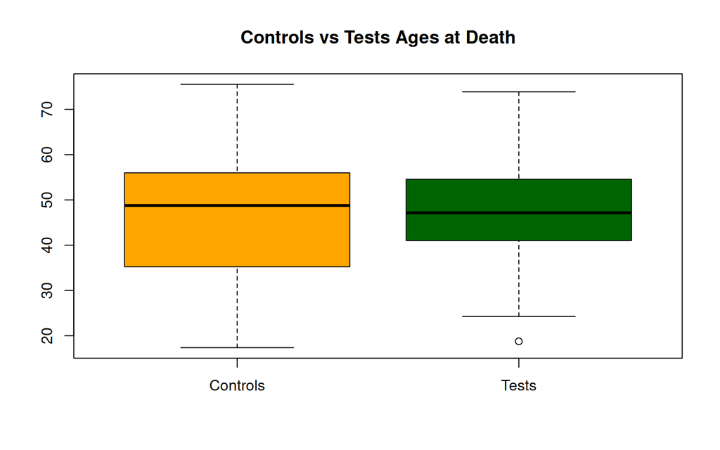

```r
# Plots ages differences between controls and test samples
boxplot(controls$age_at_death, cases$age_at_death,
        main = "Controls vs Tests Ages at Death",
        names = c("Controls", "Tests"),
        col = c("orange", "darkgreen"))
```

```r
# Isolates ages and smoking status
ages <- meta$age_at_death
status <- meta$current_smoking_status

# Evaluates difference in ages between groups
t.test(ages ~ status, data = meta)
```

```
##
##  Welch Two Sample t-test
##
## data:  ages by status
## t = 1.0239, df = 91.724, p-value = 0.3086
## alternative hypothesis: true difference in means between group case and group control is not equal to 0
## 95 percent confidence interval:
##  -1.954371  6.113100
## sample estimates:
##    mean in group case mean in group control
##              47.91580              45.83644
```

Here we see that the controls in this data set have a slightly lower average age at death, ~45.8 years old, compared to the test samples, ~47.9 years old. However, the median age of the controls is slightly higher, ~48.8 years old, compared to the test samples, ~47.16 years old. Performing a t-test on these samples confirms that there is no statistically significant difference in the age at death between smokers and non-smokers in this data set.

## 2.2 Normalization of Expression Data

Now let’s explore the expression data. We can first evaluate if normalization is necessary for our data set.

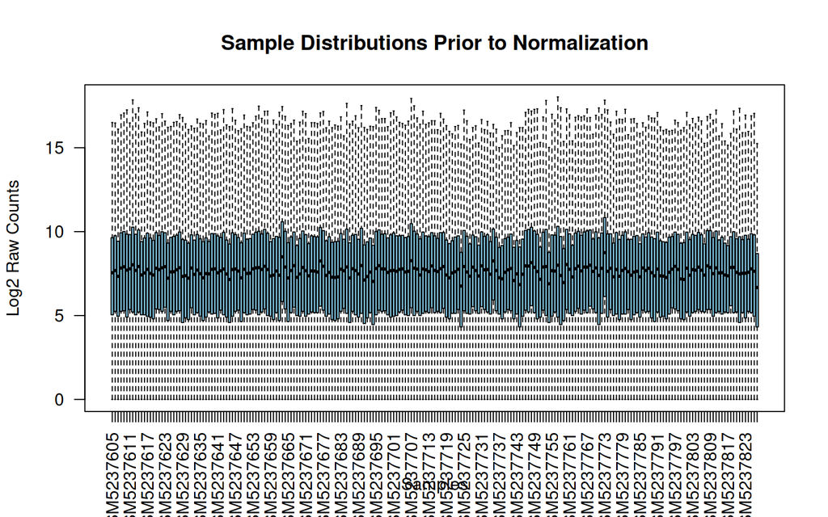

```r
# Isolates all expression data
all_expr_data <- data.filtered[, -c(1:6)]

# Isolates expression data for controls
control_expr_data <- subset(all_expr_data, select = controls$`GEO_Accession (exp)`)

# Isolates expression data for test samples
case_expr_data <- subset(all_expr_data, select = cases$`GEO_Accession (exp)`)

# Converts isolated expression data to a true numeric matrix
expr_matrix <- as.matrix(all_expr_data)

# Sets the row names as the  ENTREZID
rownames(expr_matrix) <- data.filtered$ENTREZID

# Ensures meta dataframe rows align with the columns of expr_matrix
meta_df <- as.data.frame(meta)
rownames(meta_df) <- meta_df$`GEO_Accession (exp)`
meta_df <- meta_df[colnames(expr_matrix), ]

# Reconstructs Log2 transformations for evaluation of data
logged_counts <- log2(expr_matrix + 1)

# Evaluates if expression data needs normalization
boxplot(logged_counts, main="Sample Distributions Prior to Normalization",
        las=2, outline=FALSE, col="skyblue", xlab="Samples", ylab="Log2 Raw Counts")
```

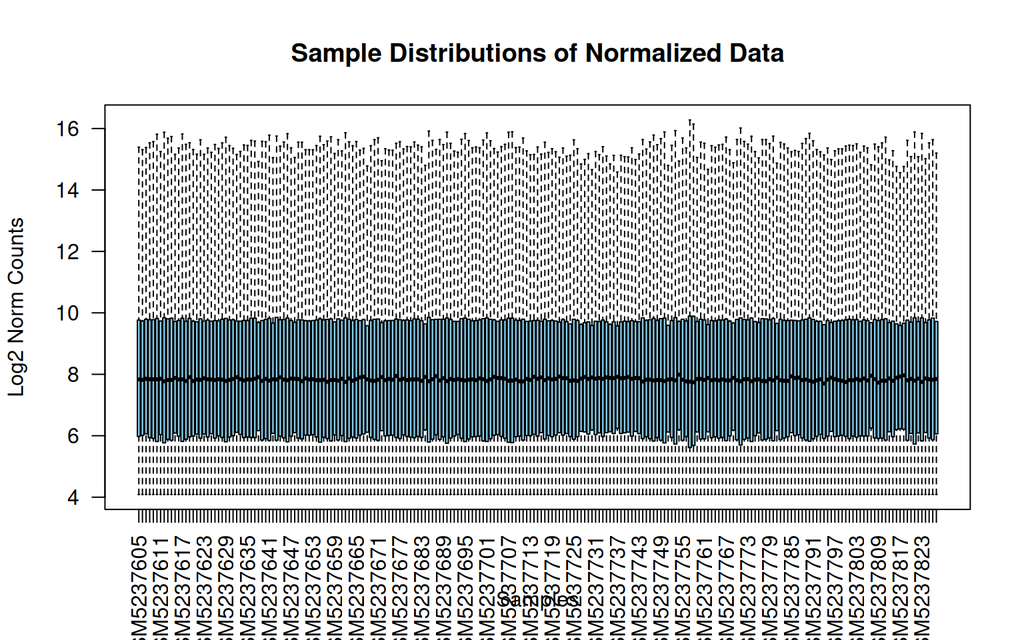

```r
# Converts isolated data to a strict numeric matrix for normalization
count_matrix <- as.matrix(all_expr_data)
rownames(count_matrix) <- data.filtered$ENTREZID

# Ensures meta dataframe rows align with the columns of count_matrix
meta_df <- as.data.frame(meta)
rownames(meta_df) <- meta_df$`GEO_Accession (exp)`
meta_df <- meta_df[colnames(count_matrix), ]

# Performs structural RNA-seq normalization (VST)
dds <- DESeqDataSetFromMatrix(countData = count_matrix,
                              colData = meta_df,
                              design = ~ current_smoking_status)
dds <- estimateSizeFactors(dds)
vsd <- varianceStabilizingTransformation(dds, blind = FALSE)
norm_counts <- assay(vsd)

# Evaluates if normalization of data was appropriate
boxplot(norm_counts, main="Sample Distributions of Normalized Data",
        las=2, outline=FALSE, col="skyblue", xlab="Samples", ylab="Log2 Norm Counts")
```

Here we see that the expression data does appear to be experiencing batch effects or technical variations prior to normalization. Once the data is normalized using VST normalization, our sample distributions no longer appear to be influenced by any potential batch effects!

## 2.3 Principle Component Analysis

With the data now normalized, we can perform PCA on the normalized data set to determine if specific data attributes result in any clustering.

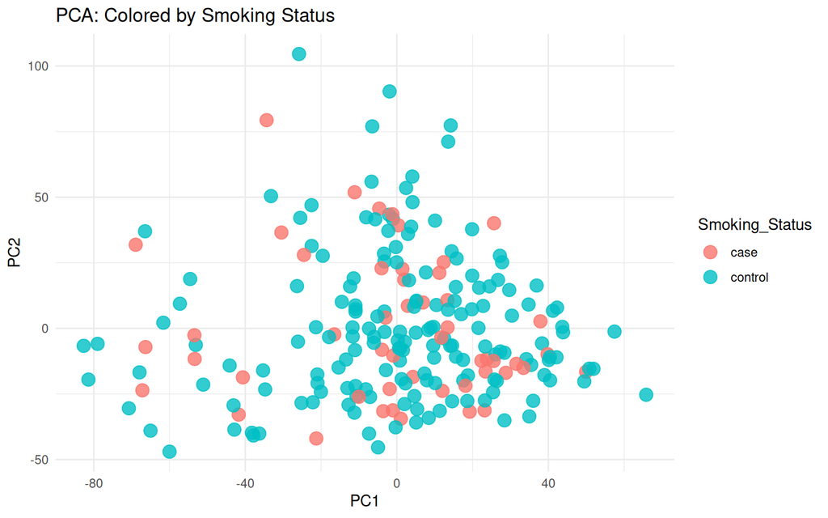

```r
# Calculates gene variance
rv <- apply(norm_counts, 1, var)

# Performs PCA on all genes in normalized data set
rv <- order(rv, decreasing = TRUE)
pca_res <- prcomp(t(norm_counts[rv, ]))

# Builds PCA data frame using metadata and first two principle components
pca_df <- data.frame(
  PC1 = pca_res$x[,1],
  PC2 = pca_res$x[,2],
  Smoking_Status = as.factor(meta_df$current_smoking_status),
  Age_at_Death   = as.numeric(meta_df$age_at_death)
)

# Checks variance in smoking status
ggplot(pca_df, aes(x=PC1, y=PC2, color=Smoking_Status)) +
  geom_point(size=4, alpha=0.8) + theme_minimal() +
  labs(title="PCA: Colored by Smoking Status", x="PC1", y="PC2")
```

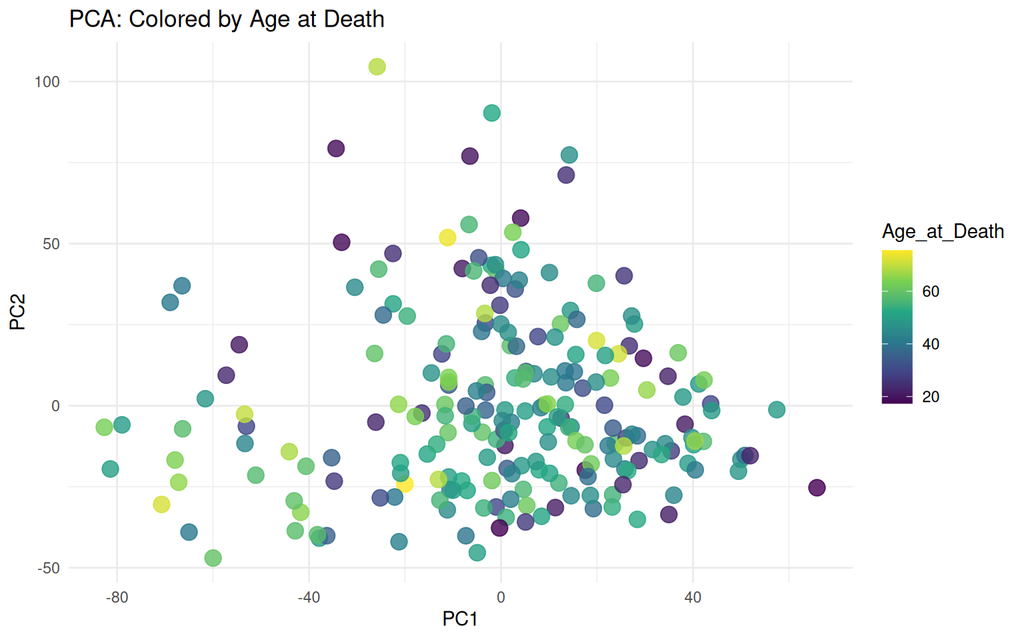

```r
# Checks variance in age at death
ggplot(pca_df, aes(x=PC1, y=PC2, color=Age_at_Death)) +
  geom_point(size=4, alpha=0.8) + scale_color_viridis_c() + theme_minimal() +
  labs(title="PCA: Colored by Age at Death", x="PC1", y="PC2")
```

```r
# Identifies genes contributing most to variance
loadings <- abs(pca_res$rotation[, 1])
top_features <- sort(loadings, decreasing = TRUE)[1:10]
top_features
```

```
##       6235       7503     145624      64805  107985363  112268323       4588
## 0.02921367 0.02507401 0.02403428 0.02391745 0.02386075 0.02361839 0.02349851
##       1524       6192  112268125
## 0.02348453 0.02326787 0.02320369
```

```r
ENTREZIDs <- names(top_features)
gene_names <- as.data.frame(data.filtered[, c("ENTREZID", "SYMBOL", "GENENAME"), with = FALSE])
matched_symbols <- gene_names$SYMBOL[match(as.character(ENTREZIDs), as.character(gene_names$ENTREZID))]
matched_details <- gene_names$GENENAME[match(as.character(ENTREZIDs), as.character(gene_names$ENTREZID))]
print(matched_symbols)
```

```
##  [1] "RPS29"        "XIST"         "PWAR1"        "P2RY12"       "LOC107985363"
##  [6] "LOC112268323" "MUC6"         "CX3CR1"       "RPS4Y1"       "LOC112268125"
```

Using variance from all genes in the data set for the PCA plot above, there appears to be no clustering based on smoking status or age with our normalized data. Additionally, when evaluating which genes contribute the most to variance, RPS29 is found to contribute the most variance in this data set. Additionally, the top 10 genes that contribute the most variance are:

- RPS29
- XIST
- PWAR1
- P2RY12
- LOC107985363
- LOC112268323
- MUC6
- CX3CR1
- RPS4Y1
- LOC112268125

# 3 Differential Expression Analysis

Now differential expression analysis can be performed on our data!

```r
# Prepares data for differential expression analysis
meta_clean <- na.omit(meta_df)
counts_clean <- count_matrix[, rownames(meta_clean)]
counts_clean <- round(counts_clean)
mode(counts_clean) <- "integer"

# Forces smoking status to be a factor
meta_clean$current_smoking_status <- factor(meta_clean$current_smoking_status,
                                            levels = c("control", "case"))

# Re-initializes DESeq dataset structure
dds_analysis <- DESeqDataSetFromMatrix(countData = counts_clean,
                                       colData = meta_clean,
                                       design = ~ current_smoking_status)

# Performs differential expression analysis based on smoking status
dds_analysis <- DESeq(dds_analysis)

# Extracts contrast results table based on significance
res <- results(dds_analysis,
               contrast = c("current_smoking_status", "case", "control"),
               alpha = 0.05,
               pAdjustMethod = "fdr")

# Corrects for bias in low count genes
target_coef <- grep("current_smoking_status_case_vs_control", resultsNames(dds_analysis), value = TRUE)
res_shrunk  <- lfcShrink(dds_analysis,
                         coef = target_coef,
                         type = "normal")
# Generate overall evaluation summary metrics
summary(res_shrunk)
```

```
##
## out of 25274 with nonzero total read count
## adjusted p-value < 0.1
## LFC > 0 (up)       : 6, 0.024%
## LFC < 0 (down)     : 54, 0.21%
## outliers [1]       : 0, 0%
## low counts [2]     : 15190, 60%
## (mean count < 380)
## [1] see 'cooksCutoff' argument of ?results
## [2] see 'independentFiltering' argument of ?results
```

In the summary table we see that, of the 25,274 genes in this data set, approximately 60 of them were differentially expressed between smokers and non-smokers. Looking closer, 6 of these genes were up-regulated while 54 were down-regulated. Since these are just genes that were either up-regulated or down-regulated, they should be filtered down to only look at significantly differentially expressed genes.

```r
# Filter out the statistically significant genes
sig_genes_df <- as.data.frame(res_shrunk)
sig_genes_df$ENTREZID <- rownames(sig_genes_df)

# Merge with gene annotations
annotations <- as.data.frame(data.filtered[, c("ENTREZID", "SYMBOL", "GENENAME"), with = FALSE])
sig_genes_annotated <- merge(sig_genes_df, annotations, by = "ENTREZID")

# Filter for significance: FDR < 0.05
sig_final_table <- subset(sig_genes_annotated, padj < 0.05)

# Print top 10 most significant differentially expressed genes
head(sig_final_table[order(sig_final_table$padj), ], 10)
```

```
##       ENTREZID  baseMean log2FoldChange      lfcSE      stat       pvalue
## 11483    23193  2415.259     -0.1400501 0.03162086 -4.432434 9.317522e-06
## 13728    29927  1465.272     -0.1229403 0.02803633 -4.386263 1.153145e-05
## 15863     4511 20546.532      0.1765037 0.03832890  4.367691 1.255672e-05
## 15910     4579 19615.359      0.1807380 0.03852433  4.451413 8.530728e-06
## 20837     6836  1487.857     -0.1263831 0.02869718 -4.405422 1.055780e-05
## 15460     4141  1556.886     -0.1177700 0.02785880 -4.228350 2.354110e-05
##             padj  SYMBOL                         GENENAME
## 11483 0.02532439   GANAB     glucosidase II alpha subunit
## 13728 0.02532439 SEC61A1 SEC61 translocon subunit alpha 1
## 15863 0.02532439    TRNC                         tRNA-Cys
## 15910 0.02532439    TRNY                         tRNA-Tyr
## 20837 0.02532439   SURF4                        surfeit 4
## 15460 0.03956475   MARS1      methionyl-tRNA synthetase 1
```

Focusing on just the statistically significant genes with an adjusted p-value < 0.05, we see that only 6 total genes meet this threshold:

- glucosidase II alpha subunit (GANAB)
- SEC61 translocon subunit alpha 1 (SEC61A1)
- tRNA-Cys (TRNC)
- tRNA-Tyr (TRNY)
- surfeit 4 (SURF4)
- methionyl-tRNA synthetase 1 (MARS1)

Both TRNC and TRNY are up-regulated with log2 Fold Change of 0.1765037 and 0.1807380, respectively. They each have an adjusted p-value of ~0.025. The other four genes are down-regulated. GANAB has a log2 Fold change of -0.1400501, SEC61A1 is -0.1229403, SURF4 is -0.1263831, and MARS1 is -0.1177700. These down-regulated genes all had an adjusted p-value of ~0.025 except for MARS1 which had an adjusted p-value of ~0.039.

Let’s check the fit of this model using the code below:

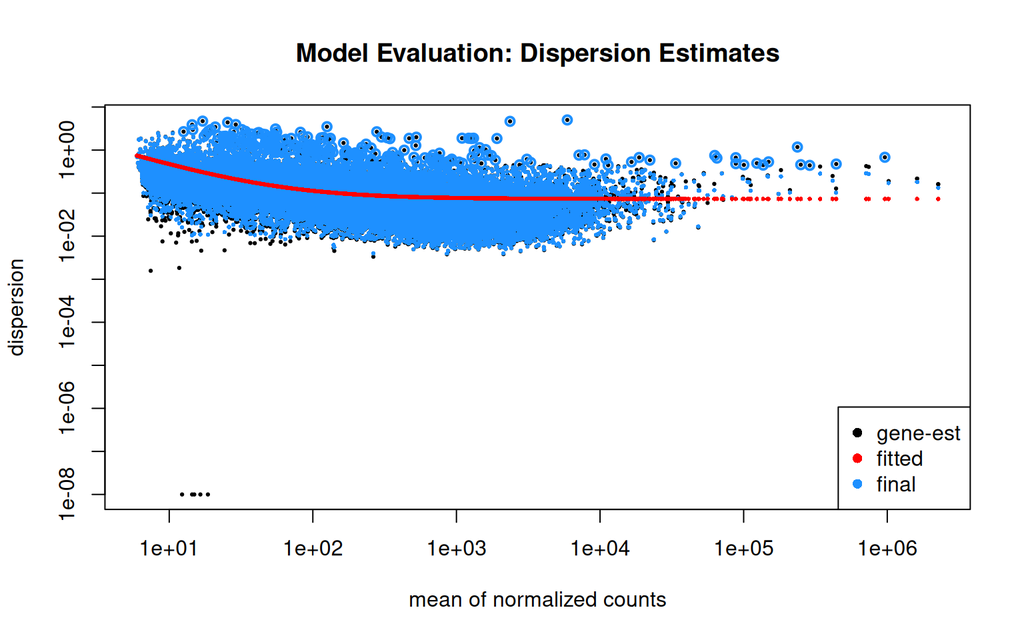

```r
# Evaluates mathematical model fit quality
plotDispEsts(dds_analysis,
             main = "Model Evaluation: Dispersion Estimates")
```

This diagnostic plot does not perfectly align with the model’s predicted trajectory, however, this is to be expected with human models. Considering the data still follows the general path of the fitted line with no other unexpected shapes or trajectories in the plot, we can infer that the model works well with our data.

A volcano plot would provide excellent visualization to show our significant genes identified earlier.

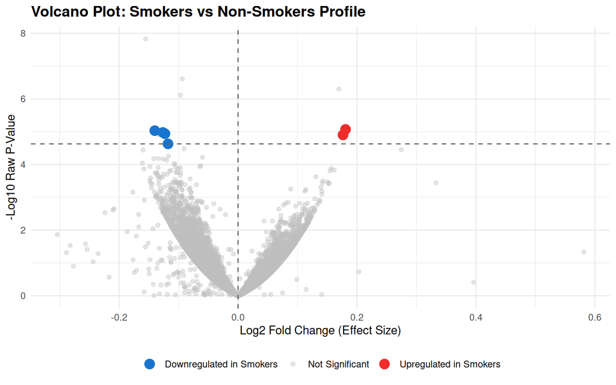

```r
# Prepares data for volcano plot
volcano_data <- as.data.frame(res_shrunk)
volcano_data$ENTREZID <- rownames(volcano_data)
annotations_df <- as.data.frame(data.filtered[, c("ENTREZID", "SYMBOL"), with = FALSE])
volcano_data <- merge(volcano_data, annotations_df, by = "ENTREZID", all.x = TRUE)

# Sets threshold for significant genes
volcano_data$Significance <- "Not Significant"
volcano_data$Significance[volcano_data$padj < 0.05 & volcano_data$log2FoldChange > 0] <- "Upregulated in Smokers"
volcano_data$Significance[volcano_data$padj < 0.05 & volcano_data$log2FoldChange < 0] <- "Downregulated in Smokers"
volcano_data$SYMBOL[is.na(volcano_data$SYMBOL) | volcano_data$SYMBOL == ""] <- volcano_data$ENTREZID[is.na(volcano_data$SYMBOL) | volcano_data$SYMBOL == ""]
sig_labels <- subset(volcano_data, padj < 0.05)

# Generates Volcano Plot
ggplot(volcano_data, aes(x = log2FoldChange, y = -log10(pvalue))) +

  # Sets visualization for non-significant genes
  geom_point(data = subset(volcano_data, Significance == "Not Significant"),
             aes(color = Significance), alpha = 0.4, size = 1.5) +

  # Sets visualization for significant genes
  geom_point(data = subset(volcano_data, Significance != "Not Significant"),
             aes(color = Significance), alpha = 1.0, size = 4) +

  # Sets colors based on significance
  scale_color_manual(values = c("Not Significant" = "grey75",
                                "Upregulated in Smokers" = "firebrick2",
                                "Downregulated in Smokers" = "dodgerblue3")) +
  geom_hline(yintercept = -log10(max(sig_labels$pvalue, na.rm=TRUE)), linetype = "dashed", col = "grey40") +
  geom_vline(xintercept = 0, linetype = "dashed", col = "grey40") +
  theme_minimal() +
  labs(title = "Volcano Plot: Smokers vs Non-Smokers Profile",
       x = "Log2 Fold Change (Effect Size)",
       y = "-Log10 Raw P-Value") +
  theme(legend.position = "bottom",
        plot.title = element_text(face = "bold", size = 14),
        legend.title = element_blank())
```

# 4 References

[1] Markunas CA, Semick SA, Quach BC, Tao R et al. Genome-wide DNA methylation differences in nucleus accumbens of smokers vs. nonsmokers. Neuropsychopharmacology 2021 Feb;46(3):554-560. PMID: 32731254